# Precipitaciones en Australia

Ithan Moreira Rut: 18865575-0

2022-06-14

Librerías usadas

```r
library(dplyr)
library(readr)
library(ggplot2)
library(SamplingUtil)
```

## Pregunta 1

Cargue la información de las lluvias de Australia. Verifique que la información se ha leído correctamente, además, de que las variables tienen el tipo correspondiente.

```r
df = read.csv("lluvia.csv")
dplyr::glimpse(df)
```

```
## Rows: 40,000
## Columns: 18
## $ Koppen      <chr> "Temperate", "Tropical", "Temperate", "Grassland", "Subtro…
## $ Estacion    <chr> "Primavera", "Oto\xf1o", "Invierno", "Primavera", "Primave…
## $ Lluvia      <dbl> 0.0, 0.0, 0.0, 0.0, 3.0, 30.0, 0.0, 0.2, 0.0, 0.0, 0.0, 1.…
## $ VelRafaga   <int> 37, 28, 24, 43, 35, 44, 48, 37, 56, 33, 35, 35, 52, 67, 22…
## $ Vel9am      <int> 19, 2, 0, 24, 9, 11, 15, 15, 11, 17, 19, 17, 11, 37, 2, 4,…
## $ Vel3pm      <int> 26, 19, 9, 22, 24, 33, 24, 15, 33, 22, 26, 7, 22, 13, 9, 1…
## $ Hum9am      <int> 85, 68, 95, 21, 62, 98, 58, 55, 73, 78, 74, 88, 41, 90, 92…
## $ Hum3pm      <int> 46, 62, 79, 10, 57, 74, 65, 47, 58, 61, 42, 67, 55, 76, 72…
## $ Pres9am     <dbl> 1024.8, 1013.9, 1022.9, 1023.3, 1018.5, 1015.5, 1023.0, 10…
## $ Pre3pm      <dbl> 1020.6, 1010.4, 1017.7, 1018.5, 1015.1, 1011.6, 1021.4, 10…
## $ Temp9am     <dbl> 10.9, 26.7, 6.2, 15.0, 20.4, 23.2, 17.2, 17.4, 21.4, 23.0,…
## $ Nub9am      <int> 1, 1, 7, 0, 7, 7, 5, 6, 5, 8, 5, 7, 5, 8, 8, 5, 8, 7, 7, 1…
## $ Nub3pm      <int> 1, 1, 8, 0, 8, 6, 5, 8, 7, 7, 1, 7, 7, 7, 7, 6, 8, 5, 5, 1…
## $ Evaporacion <dbl> 2.0, 4.8, 0.4, 7.8, 4.8, 1.8, 5.2, 4.2, 5.8, 5.2, 4.6, 6.6…
## $ Sol         <dbl> 8.0, 10.6, 0.1, 11.3, 0.4, 0.3, 10.2, 3.6, 8.7, 1.5, 2.0, …
## $ Temp3pm     <dbl> 18.8, 29.2, 11.5, 21.7, 22.6, 27.0, 20.0, 17.4, 25.7, 25.6…
## $ LluviaHoy   <int> 0, 0, 0, 0, 1, 1, 0, 0, 0, 0, 0, 1, 0, 1, 1, 0, 1, 0, 1, 0…
## $ target      <dbl> 15.8, 11.4, 9.4, 18.1, 6.7, 5.1, 10.9, 3.9, 9.8, 5.4, 11.4…
```

Finalmente obtenga una muestra aleatoria de simple de tamaño 5000. Para poder replicar sus resultados, es requerido que antes de cada muestreo aleatorio fije una semilla utilizando la función set.seed()

```r
set.seed(200) #Semilla fijada en 200
df_muestra = df %>% dplyr::sample_n(size=5000, remplace = FALSE)
```

## Pregunta 2

Utilizando la muestra aleatoria obtenida en la pregunta 1, indique:

### A) Probabilidad de que llueva hoy

```r
df_muestra$LluviaHoy %>% mean()*100
```

```
## [1] 22.26
```

Data Completa

```r
df$LluviaHoy %>% mean()*100
```

```
## [1] 21.9625
```

### B) Probabilidad de que un día tenga menos de 8 horas de sol

```r
df_muestra %>% filter(Sol<8) %>% summarise(media = n()/nrow(df_muestra)*100 )
```

```
##   media
## 1  42.9
```

Data Completa

```r
df %>% filter(Sol<8)%>% select(Sol) %>% summarise(media = n()/nrow(df)*100 )
```

```
##     media
## 1 44.2125
```

### C) Probabilidad de que la temperatura a las 3pm sea sobre 20°C en invierno

```r
df_muestra %>% filter(Temp3pm>20 & Estacion=="Invierno") %>% summarise(media = n()/nrow(df_muestra)*100 )
```

```
##   media
## 1  6.54
```

Data Completa

```r
df %>% filter(Temp3pm>20 & Estacion=="Invierno") %>% summarise(media = n()/nrow(df)*100 )
```

```
##    media
## 1 6.5725
```

### D) Probabilidad de que lluevan entre 5mm y 10mm, en un clima Koppen Subtropical

```r
df_muestra %>% filter(Koppen=="Subtropical" & Lluvia>5.0 & Lluvia<10.0 ) %>%
           summarise(media = n()/nrow(df_muestra)*100 )
```

```
##   media
## 1  1.92
```

Data Completa

```r
df %>% filter(Koppen=="Subtropical" & Lluvia>5.0 & Lluvia<10.0) %>% summarise(media = n()/nrow(df)*100 )
```

```
##   media
## 1 1.665
```

### E) Repita las preguntas anteriores utilizando el conjunto completo de datos y compare sus resultados. La muestra obtenida es representativa?,¿cómo mejoraría la muestra aleatoria?

```
La muestra es representativa en la temperatura a las 3pm y los milímetros de lluvia, se podrían probar otros tipos de muestreos para evaluar los datos.
```

## Pregunta 3

Utilice un muestreo estratificado de tamaño 5000 según el indice Koppen de la zona.

```r
df %>% select(Koppen) %>% table() %>% prop.table()
```

```
## Koppen
##      Desert   Grassland Subtropical   Temperate    Tropical
##    0.029850    0.088250    0.356350    0.385875    0.139675
```

```r
Estrato=SamplingUtil::nstrata(5000, wh = c(0.029850, 0.088250,0.356350,0.385875,0.139675))

#MuestraDesert
set.seed(200) #Semilla fijada en 200
MuestraDesert = df %>% filter(Koppen=="Desert") %>% dplyr::sample_n(size=Estrato[1], remplace = FALSE)
#MuestraDesert
set.seed(200) #Semilla fijada en 200
MuestraGrassland = df %>% filter(Koppen=="Grassland") %>% dplyr::sample_n(size=Estrato[2], remplace = FALSE)
#MuestraDesert
set.seed(200) #Semilla fijada en 200
MuestraSubtropical = df %>% filter(Koppen=="Subtropical") %>% dplyr::sample_n(size=Estrato[3], remplace = FALSE)
#MuestraDesert
set.seed(200) #Semilla fijada en 200
MuestraTemperate = df %>% filter(Koppen=="Temperate") %>% dplyr::sample_n(size=Estrato[4], remplace = FALSE)
#MuestraDesert
set.seed(200) #Semilla fijada en 200
MuestraTropical = df %>% filter(Koppen=="Tropical") %>% dplyr::sample_n(size=Estrato[5], remplace = FALSE)

df_muestraEstratificado = rbind(MuestraDesert, MuestraGrassland, MuestraSubtropical,
                                MuestraTemperate, MuestraTropical)
rm(MuestraDesert); rm(MuestraGrassland); rm(MuestraSubtropical)
rm(MuestraTemperate); rm(MuestraTropical);rm(Estrato)
```

La proporción de la muestra por zona Koppen debe ser equivalente a la proporción real de la población.

```r
prop.table(table(df_muestraEstratificado$Koppen))
```

```
##
##      Desert   Grassland Subtropical   Temperate    Tropical
##  0.02998201  0.08834699  0.35618629  0.38576854  0.13971617
```

Utilizando la muestra estratificada indique:

### A) Probabilidad de que llueva hoy

```r
df_muestraEstratificado$LluviaHoy %>% mean()*100
```

```
## [1] 21.56706
```

### B) Probabilidad de que un día tenga menos de 8 horas de sol

```r
df_muestraEstratificado %>% filter(Sol<8) %>%
  summarise(media = n()/nrow(df_muestraEstratificado)*100 )
```

```
##      media
## 1 44.21347
```

### C) Probabilidad de que la temperatura a las 3pm sea sobre 20°C en invierno

```r
df_muestraEstratificado %>% filter(Temp3pm>20 & Estacion=="Invierno") %>%
  summarise(media = n()/nrow(df_muestraEstratificado)*100 )
```

```
##      media
## 1 6.955827
```

### D) Probabilidad de que lluevan entre 5mm y 10mm, en un clima Koppen Subtropical

```r
df_muestraEstratificado %>% filter(Koppen=="Subtropical" & Lluvia>5.0 & Lluvia<10.0) %>%
  summarise(media = n()/nrow(df_muestraEstratificado)*100 )
```

```
##      media
## 1 1.479113
```

Han mejorado los resultados al utilizar un muestreo aleatorio estratificado en comparación al muestreo aleatorio simple?

[output not shown]

## Pregunta 4

Utilizando la muestra estratificada, determine un intervalo de confianza al 95%:

### A) Para el promedio de temperatura de Australia a las 9am

```r
ConfPromedio9=df_muestraEstratificado%>% select(Temp9am)%>% t.test(conf.level=0.95)

ConfPromedio9$conf.int
```

```
## [1] 17.93521 18.30185
## attr(,"conf.level")
## [1] 0.95
```

```r
rm(ConfPromedio9)
```

Data Completa

```r
df$Temp9am %>% mean()
```

```
## [1] 18.08529
```

### B) Para el promedio de temperatura de Australia a las 9am en las distintas estaciones del año. Compare sus intervalos

- **Verano**

```r
df_muestraEstratificado%>% filter(Estacion=="Verano") %>% select(Temp9am)%>% t.test(conf.level=0.95)
```

```
##
##  One Sample t-test
##
## data:  .
## t = 149.05, df = 1145, p-value < 2.2e-16
## alternative hypothesis: true mean is not equal to 0
## 95 percent confidence interval:
##  22.73771 23.34432
## sample estimates:
## mean of x
##  23.04101
```

Data Completa

```r
df %>% filter(Estacion=="Verano") %>% summarise(media = mean(Temp9am) )
```

```
##      media
## 1 22.84047
```

- **Otoño**

```r
df_muestraEstratificado%>% filter(Estacion=="Oto\xf1o") %>% select(Temp9am)%>% t.test(conf.level=0.95)
```

```
##
##  One Sample t-test
##
## data:  .
## t = 116.35, df = 1318, p-value < 2.2e-16
## alternative hypothesis: true mean is not equal to 0
## 95 percent confidence interval:
##  18.01701 18.63500
## sample estimates:
## mean of x
##    18.326
```

Data Completa

```r
df %>% filter(Estacion=="Oto\xf1o")%>% summarise(media = mean(Temp9am) )
```

```
##      media
## 1 18.25433
```

- **Invierno**

```r
df_muestraEstratificado%>% filter(Estacion=="Invierno") %>% select(Temp9am)%>% t.test(conf.level=0.95)
```

```
##
##  One Sample t-test
##
## data:  .
## t = 86.217, df = 1298, p-value < 2.2e-16
## alternative hypothesis: true mean is not equal to 0
## 95 percent confidence interval:
##  12.68185 13.27242
## sample estimates:
## mean of x
##  12.97714
```

Data Completa

```r
df %>% filter(Estacion=="Invierno") %>% summarise(media = mean(Temp9am) )
```

```
##      media
## 1 12.75787
```

- **Primavera**

```r
df_muestraEstratificado%>% filter(Estacion=="Primavera") %>% select(Temp9am)%>% t.test(conf.level=0.95)
```

```
##
##  One Sample t-test
##
## data:  .
## t = 111.25, df = 1238, p-value < 2.2e-16
## alternative hypothesis: true mean is not equal to 0
## 95 percent confidence interval:
##  18.40465 19.06540
## sample estimates:
## mean of x
##  18.73503
```

Data Completa

```r
df %>% filter(Estacion=="Primavera") %>% summarise(media = mean(Temp9am) )
```

```
##      media
## 1 18.76364
```

### C) Para la proporción de días con lluvias (variable lluviaHoy)

```r
df_muestraEstratificado%>% select(LluviaHoy) %>% table()
```

```
## LluviaHoy
##    0    1
## 3924 1079
```

```r
prop.test(x=1079,n=5003,conf.level=0.95)$conf.int
```

```
## [1] 0.2043964 0.2273849
## attr(,"conf.level")
## [1] 0.95
```

Data Completa

```r
df$LluviaHoy %>% mean()
```

```
## [1] 0.219625
```

### D) Obtenga los indicadores puntuales en cada caso para los datos completos, ¿estos están contenidos en el intervalo de confianza propuesto?

```
Si, todos estaba entre los intervalos de confianza de la muestra.
```

## Pregunta 5

Utilizando la muestra estratificada, pruebe al 10% de significancia las siguientes afirmaciones:

### A) La temperatura promedio a a las 9am en Australia es menor a los 18°C

```r
H0>=18 ; H1<18
```

```r
df_muestraEstratificado %>% select(Temp9am) %>% t.test(mu=18,alternative= "l", conf.level=0.90)
```

```
##
##  One Sample t-test
##
## data:  .
## t = 1.2676, df = 5002, p-value = 0.8975
## alternative hypothesis: true mean is less than 18
## 90 percent confidence interval:
##      -Inf 18.23838
## sample estimates:
## mean of x
##  18.11853
```

```
No existe evidencia estadística suficiente para rechazar H0
```

Data Completa

```r
df$Temp9am %>% mean()
```

```
## [1] 18.08529
```

### B) Las horas de sol en una zona Koppen desértica es de 9 horas

```r
H0=9 ; H1!=9
```

```r
df_muestraEstratificado %>%
  filter(Koppen == "Desert") %>%
  select(Sol) %>% t.test(mu=9, alternative = "t", conf.level = 0.9)
```

```
##
##  One Sample t-test
##
## data:  .
## t = -0.71293, df = 149, p-value = 0.477
## alternative hypothesis: true mean is not equal to 9
## 90 percent confidence interval:
##  8.324606 9.268727
## sample estimates:
## mean of x
##  8.796667
```

```
No existe evidencia estadística suficiente para rechazar H0
```

Data Completa

```r
df %>% filter(Koppen=="Desert") %>% summarise(media = mean(Sol) )
```

```
##      media
## 1 8.941792
```

### C) El porcentaje de humedad a las 3pm en invierno en una zona tropical es menor al 45%

```r
H0>=65 ; H1<65
```

```r
(df_muestraEstratificado$Hum3pm < 45) %>%  table() %>% prop.test(p = 0.65 , alternative= "l", conf.level=0.9)
```

```
##
##  1-sample proportions test with continuity correction
##
## data:  ., null probability 0.65
## X-squared = 30.543, df = 1, p-value = 1.633e-08
## alternative hypothesis: true p is less than 0.65
## 90 percent confidence interval:
##  0.00000 0.62152
## sample estimates:
##         p
## 0.6126324
```

```
Existe evidencia estadística suficiente para rechazar H0
```

Data Completa

```r
(df$Hum3pm < 45) %>% table() %>% prop.table()*100
```

```
## .
##  FALSE   TRUE
## 61.745 38.255
```

### D) En invierno, la humedad a las 3pm es igual en una zona tropical y una zona subtropical

```r
H0:tropical==subtropical ; H1:tropical!=subtropical
```

```r
Mtropical=df_muestraEstratificado %>%
                        filter(Estacion=="Invierno" & Koppen=="Tropical" ) %>%
                        select(Hum3pm)

Msubtropical=df_muestraEstratificado %>%
                        filter(Estacion=="Invierno" & Koppen=="Subtropical") %>%
                        select(Hum3pm)

t.test(x=Msubtropical$Hum3pm, y=Mtropical$Hum3pm,
       mu = 0, alternative = "t", var.equal = FALSE)
```

```
##
##  Welch Two Sample t-test
##
## data:  Msubtropical$Hum3pm and Mtropical$Hum3pm
## t = 4.2145, df = 331.02, p-value = 3.232e-05
## alternative hypothesis: true difference in means is not equal to 0
## 95 percent confidence interval:
##  3.430519 9.436082
## sample estimates:
## mean of x mean of y
##  52.70954  46.27624
```

```r
rm(Mtropical);rm(Msubtropical)
```

```
Existe evidencia estadística suficiente para rechazar H0
```

Data Completa

```r
df %>% filter(Estacion=="Invierno" & Koppen=="Tropical" ) %>%
  select(Hum3pm) %>% summarise(media = mean(Hum3pm) )
```

```
##      media
## 1 46.13137
```

```r
df %>% filter(Estacion=="Invierno" & Koppen=="Subtropical") %>%
  select(Hum3pm) %>% summarise(media = mean(Hum3pm) )
```

```
##      media
## 1 52.44091
```

### E) Obtenga los indicadores puntuales en cada caso para los datos completos y compare sus resultados.

```
La data completa refleja las hipótesis, aceptando la pregunta B donde al ser una diferencia pequeña no se alcanza a rechazar la H0.
```

## Pregunta 6

### A) Para el promedio de temperatura de Australia a las 9am

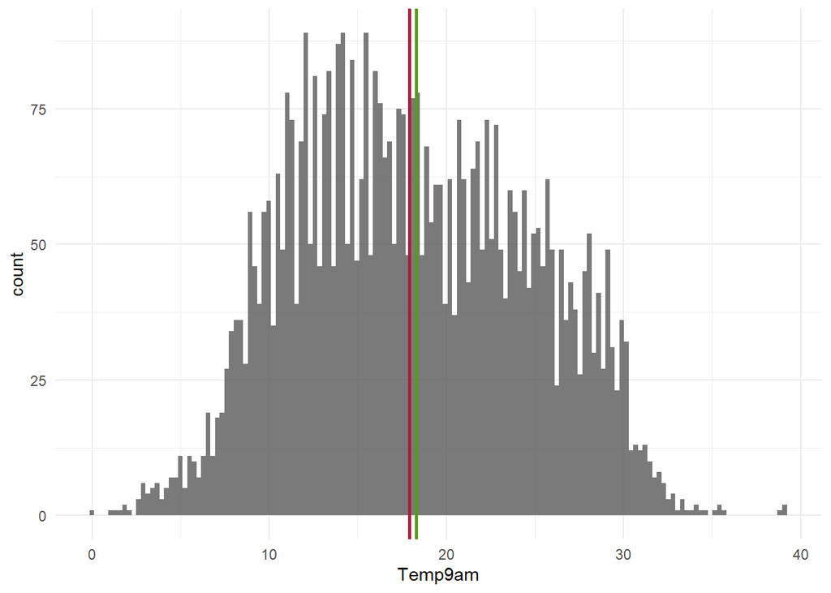

```r
df_muestraEstratificado %>%
  select(Temp9am) %>%
  ggplot(., aes(x = Temp9am)) +
  geom_histogram(position = "identity", bins = 150, alpha = 0.8) +
  scale_fill_manual(values = c("#98ECAE", "#EC98A9"))+
  geom_vline(xintercept = 17.93521,
             color = "#A61F3A", size=1)+
  geom_vline(xintercept = 18.30185,
             color = "#5A9A16", size=1,show.legend = "Intervalo")+
  theme_minimal()
```

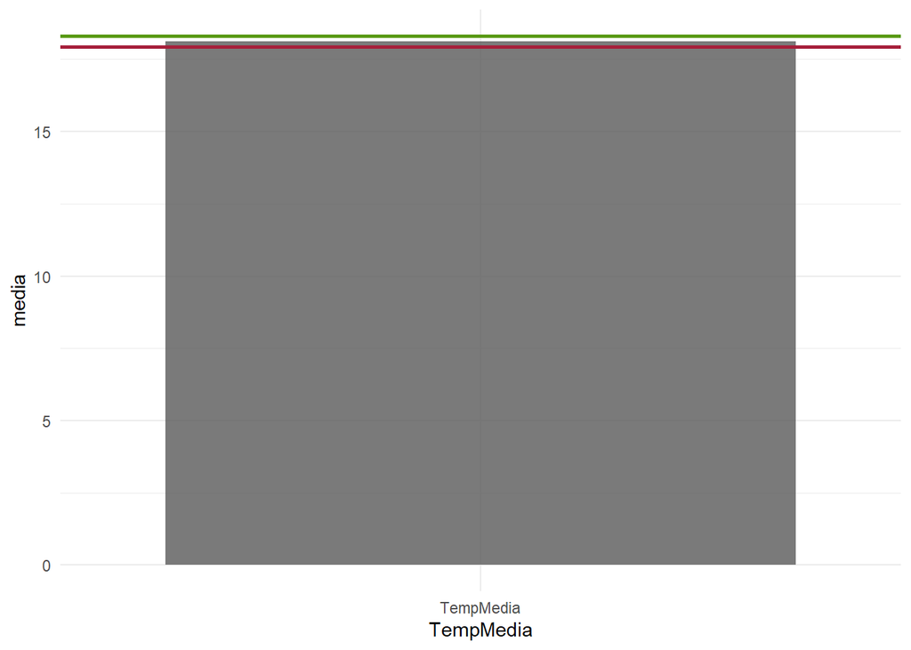

```r
df_muestraEstratificado%>%
  select(Temp9am) %>% summarise(media = mean(Temp9am)) %>% mutate(TempMedia='TempMedia') %>%

  ggplot(., aes(x = TempMedia, y=media)) +
  geom_bar( stat = "identity", alpha = 0.8) +
  geom_hline(yintercept = 17.93521,
             color = "#A61F3A", size=1)+
  geom_hline(yintercept = 18.30185,
             color = "#5A9A16", size=1)+
  theme_minimal()
```

### B) Para el promedio de temperatura de Australia a las 9am en las distintas estaciones del año. Compare sus intervalos

- **Verano**

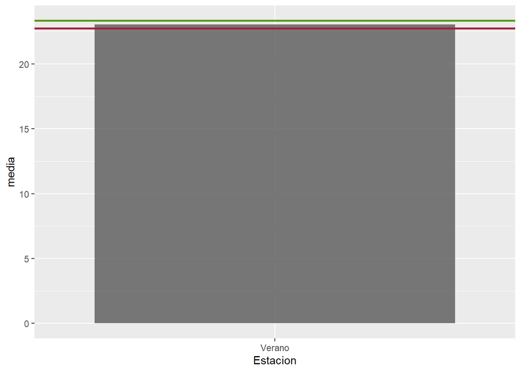

```r
df_muestraEstratificado%>%  filter(Estacion=="Verano")%>%
  select(Temp9am,Estacion)%>% group_by(Estacion) %>% summarise(media = mean(Temp9am)) %>%
ggplot(., aes(x = Estacion, y=media)) +
  geom_bar( stat = "identity", alpha = 0.8) +
  geom_hline(yintercept = 22.73771,
             color = "#A61F3A", size=1)+
  geom_hline(yintercept = 23.34432,
             color = "#5A9A16", size=1)
```

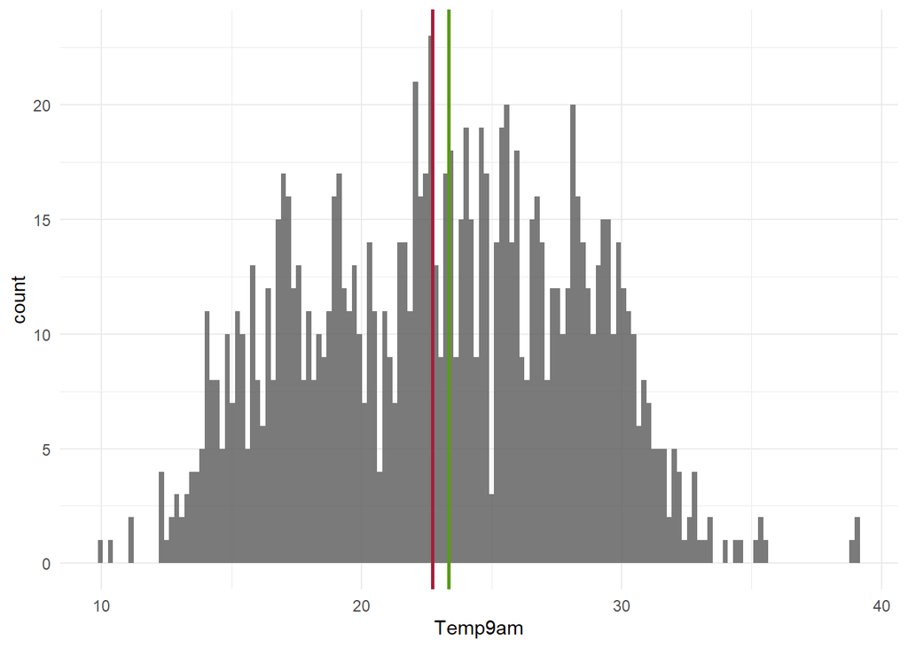

```r
df_muestraEstratificado%>%  filter(Estacion=="Verano")%>%
  select(Temp9am,Estacion)%>%
  ggplot(., aes(x = Temp9am)) +
  geom_histogram(position = "identity", bins = 150, alpha = 0.8) +
  scale_fill_manual(values = c("#98ECAE", "#EC98A9"))+
  geom_vline(xintercept = 22.73771,
             color = "#A61F3A", size=1)+
  geom_vline(xintercept = 23.34432,
             color = "#5A9A16", size=1,show.legend = "Intervalo")+
  theme_minimal()
```

- **Otoño**

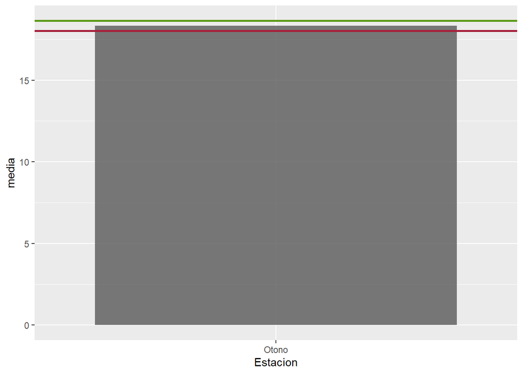

```r
df_muestraEstratificado%>%  filter(Estacion=="Oto\xf1o")%>%
  select(Temp9am)%>%mutate(Estacion="Otono") %>% group_by(Estacion) %>% summarise(media = mean(Temp9am)) %>%
  ggplot(., aes(x = Estacion, y=media)) +
  geom_bar( stat = "identity", alpha = 0.8) +
  geom_hline(yintercept = 18.01701,
             color = "#A61F3A", size=1)+
  geom_hline(yintercept =18.63500,
             color = "#5A9A16", size=1)
```

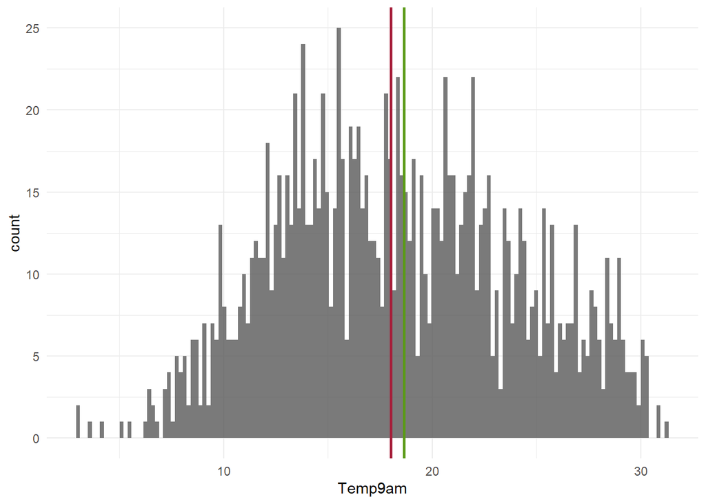

```r
df_muestraEstratificado%>%  filter(Estacion=="Oto\xf1o")%>%
  select(Temp9am)%>%
  ggplot(., aes(x = Temp9am)) +
  geom_histogram(position = "identity", bins = 150, alpha = 0.8) +
  scale_fill_manual(values = c("#98ECAE", "#EC98A9"))+
  geom_vline(xintercept = 18.01701,
             color = "#A61F3A", size=1)+
  geom_vline(xintercept = 18.63500,
             color = "#5A9A16", size=1,show.legend = "Intervalo")+
  theme_minimal()
```

- **Invierno**

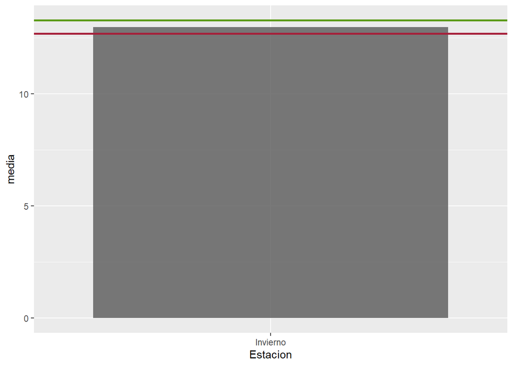

```r
df_muestraEstratificado%>%  filter(Estacion=="Invierno")%>%
  select(Temp9am,Estacion)%>% group_by(Estacion) %>% summarise(media = mean(Temp9am)) %>%
  ggplot(., aes(x = Estacion, y=media)) +
  geom_bar( stat = "identity", alpha = 0.8) +
  geom_hline(yintercept = 12.68185,
             color = "#A61F3A", size=1)+
  geom_hline(yintercept =13.27242,
             color = "#5A9A16", size=1)
```

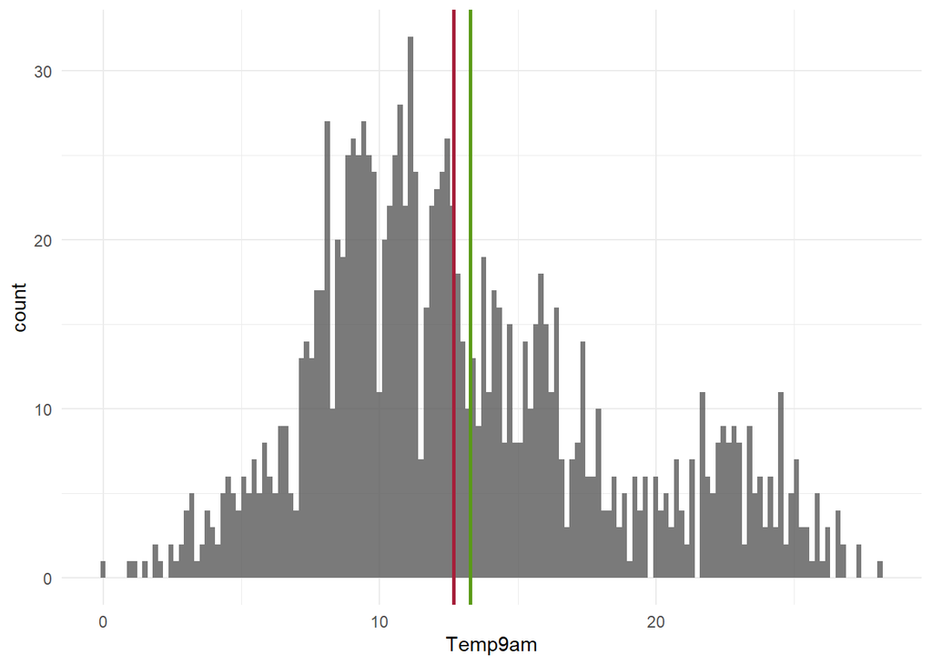

```r
df_muestraEstratificado%>%  filter(Estacion=="Invierno")%>%
  select(Temp9am,Estacion)%>%
  ggplot(., aes(x = Temp9am)) +
  geom_histogram(position = "identity", bins = 150, alpha = 0.8) +
  scale_fill_manual(values = c("#98ECAE", "#EC98A9"))+
  geom_vline(xintercept = 12.68185,
             color = "#A61F3A", size=1)+
  geom_vline(xintercept = 13.27242,
             color = "#5A9A16", size=1,show.legend = "Intervalo")+
  theme_minimal()
```

- **Primavera**

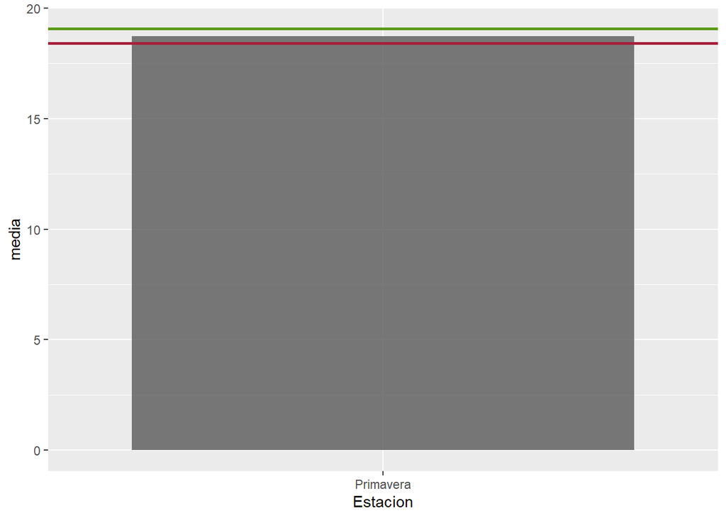

```r
df_muestraEstratificado%>%  filter(Estacion=="Primavera")%>%
  select(Temp9am,Estacion)%>% group_by(Estacion) %>% summarise(media = mean(Temp9am)) %>%
  ggplot(., aes(x = Estacion, y=media)) +
  geom_bar( stat = "identity", alpha = 0.8) +
  geom_hline(yintercept = 18.40465,
             color = "#A61F3A", size=1)+
  geom_hline(yintercept =19.06540,
             color = "#5A9A16", size=1)
```

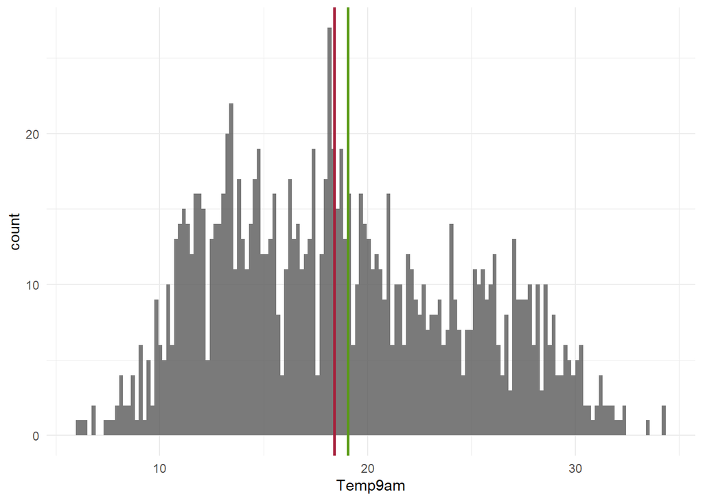

```r
df_muestraEstratificado%>%  filter(Estacion=="Primavera")%>%
  select(Temp9am,Estacion)%>%
  ggplot(., aes(x = Temp9am)) +
  geom_histogram(position = "identity", bins = 150, alpha = 0.8) +
  scale_fill_manual(values = c("#98ECAE", "#EC98A9"))+
  geom_vline(xintercept = 18.40465,
             color = "#A61F3A", size=1)+
  geom_vline(xintercept = 19.06540,
             color = "#5A9A16", size=1,show.legend = "Intervalo")+
  theme_minimal()
```

### C) Para la proporción de días con lluvias (variable lluviaHoy)

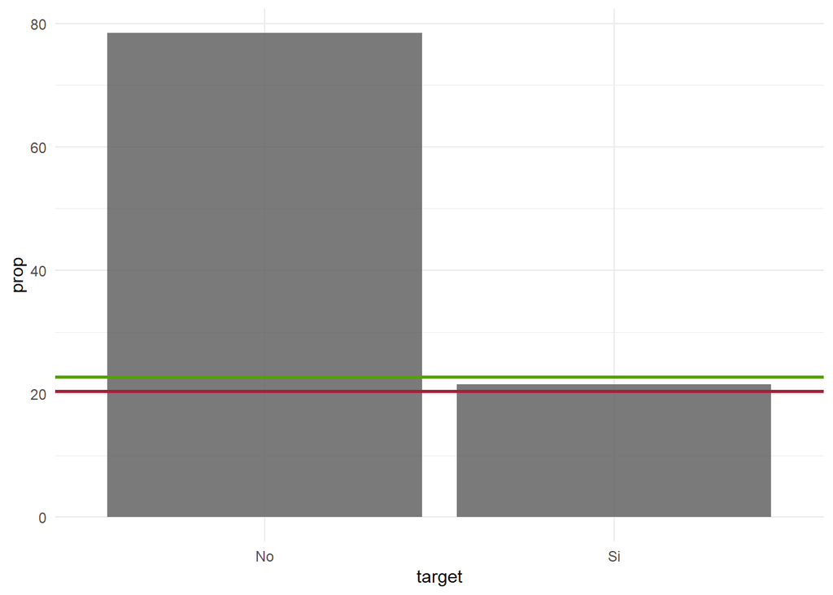

```r
df_muestraEstratificado%>%
  select(LluviaHoy)%>% mutate(target=case_when(LluviaHoy==0~ "No",
                                               LluviaHoy==1~"Si")) %>%
  group_by(target) %>%summarise(contador = n()) %>% mutate(prop=contador/sum(contador)*100) %>%

  ggplot(., aes(x = target, y=prop)) +
  geom_bar( stat = "identity", alpha = 0.8) +
  geom_hline(yintercept = 20.43964,
             color = "#A61F3A", size=1)+
  geom_hline(yintercept = 22.73849,
             color = "#5A9A16", size=1)+
  theme_minimal()
```